# What Predicts Good 3PT Shooting?

Matt Saraceno

2024-07-15

### **Introduction**

Three point shooting(3PT) is a critical part of modern basketball. The best teams in the National Basketball Associate(NBA) are all in an arms race to load up on the best three point shooters in the world. With so many players being evaluated on their ability to shoot the three ball, what data can be used to help predict a players ability to make three pointers?

The goal of this report is to predict a players ability to hit three pointers by looking at three different factors: free-throw(FT) percentage, mid-range percentage, and the position they play.

### **Question #1: Does the ability to make free-throws influence three-point shooting?**

We have all heard this before in one way or another, “A player’s ability to make free throws is an indicator that a player is, or can be, a great shooter”. This line of thinking has been repeated so many times across sports media that it has become basketball common knowledge, but is it true?

I have decided to take a look at last years shooting totals from all 572 NBA players, and see if there truly is an correlation between the two statistics.

The code below gives a quick preview of what our data looks like.

```r
library(tidyverse)
library(readxl)
mydata1 <- read_excel("D:/Data Analyst/3pt shooting/3pt_shooting.xlsx")
head(mydata1)
```

```
## # A tibble: 6 × 30
##      Rk Player    Pos     Age Tm        G    GS    MP    FG   FGA FG_per three_P
##   <dbl> <chr>     <chr> <dbl> <chr> <dbl> <dbl> <dbl> <dbl> <dbl>  <dbl>   <dbl>
## 1     1 Precious… PF       24 TOT      74    18  1624   235   469  0.501      26
## 2     2 Bam Adeb… C        26 MIA      71    71  2416   530  1017  0.521      15
## 3     3 Ochai Ag… SG       23 TOT      78    28  1641   178   433  0.411      62
## 4     4 Santi Al… PF       23 MEM      61    35  1618   247   568  0.435     106
## 5     5 Nickeil … SG       25 MIN      82    20  1921   236   538  0.439     131
## 6     6 Grayson … SG       28 PHO      75    74  2513   340   682  0.499     205
## # ℹ 18 more variables: three_PA <dbl>, threeP_percent <dbl>, two_P <dbl>,
## #   two_PA <dbl>, twoP_per <dbl>, eFG_per <dbl>, FT <dbl>, FTA <dbl>,
## #   FT_percent <dbl>, ORB <dbl>, DRB <dbl>, TRB <dbl>, AST <dbl>, STL <dbl>,
## #   BLK <dbl>, TOV <dbl>, PF <dbl>, PTS <dbl>
```

Before we can start to do any analysis, we must first filter out some data. Not every NBA player this season shot enough FTs or three-pointers to give us any meaningful data. This report will look at only players that have attempted at least 150 FTs and attempted at least 85 three pointers.

Below is a graph of charting the two statistics:

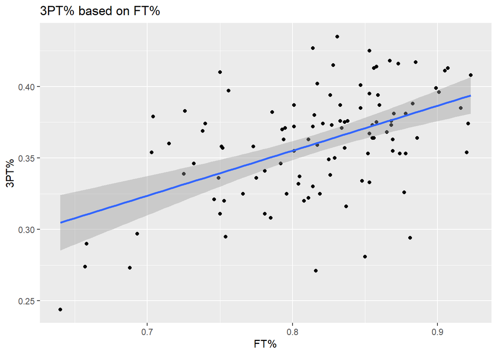

```r
filtered_mydata1 <- mydata1[mydata1$FTA >= 150 & mydata1$three_PA >=85, ]
ggplot(filtered_mydata1, aes(x = FT_percent, y = threeP_percent))+
  geom_point()+
  ggtitle("3PT% based on FT%")+
  xlab("FT%")+
  ylab("3PT%")+
  geom_smooth(method = 'lm')
```

Out of the 572 initial players that were observed, only 106 made the cut after our filtering. The median FT percentage from this group of players is 81.62% and their 3PT shooting percentage is 36.03%. Those are some pretty solid numbers from some of the best players in the world.

The initial thoughts from examining this graph, is that there seems to be a positive correlation between the two stats. A trend line is added to the graph to provide the audience the direction of the data. The data is not heavily correlated due to the random nature that the data presents. That is reinforced by our correlation coefficient.

```r
cor(filtered_mydata1$FT_percent, filtered_mydata1$threeP_percent)
```

```
## [1] 0.5059518
```

Correlation coefficient provides a measurement to determine if there is any significant relationship between two variables. The closer the correlation coefficient is to 1, the stronger the relationship is. The correlation coefficient for this data is .505918. A correlation coefficient of less than .7 is not strong enough to infer that high FT percentage is linked to good three point shooting.

### **Question #2: Does a player’s ability to make mid-range jump shots influence a player ability to make three-pointers?**

```r
mydata2 <- read_excel("D:/Data Analyst/3pt shooting/shooting_advanced.xlsx")
filtered_mydata2 <- mydata2[mydata2$ten_sixteenAperbyDistance >= .125 & mydata2$Games >= 25, ]
filtered_mydata3 <- filtered_mydata2 %>%  filter(!row_number() %in% c(53, 68))
filtered_mydata4 <- subset(filtered_mydata3, !is.na(filtered_mydata3$threep_fgperbyDistance))
head(filtered_mydata4)
```

```
## # A tibble: 6 × 29
##      Rk Player     Pos     Age Tm    Games    MP `FG%` Dist. twoPA_perbyDistance
##   <dbl> <chr>      <chr> <dbl> <chr> <dbl> <dbl> <dbl> <dbl>               <dbl>
## 1     2 Bam Adeba… C        26 MIA      71  2416 0.521   8.5               0.959
## 2    10 Kyle Ande… PF       30 MIN      79  1782 0.46    9                 0.889
## 3    13 Cole Anth… PG       23 ORL      81  1817 0.435  14.9               0.64
## 4    17 Deandre A… C        25 POR      55  1784 0.57    8.9               0.987
## 5    25 Paolo Ban… PF       21 ORL      80  2799 0.455  12.6               0.751
## 6    28 Dominick … PF       20 SAS      33   420 0.496   7.4               0.92
## # ℹ 19 more variables: zero_3AperbyDistance <dbl>,
## #   three_tenAperbyDistance <dbl>, ten_sixteenAperbyDistance <dbl>,
## #   sixteen_threepAperbyDistance <dbl>, threepAperbyDistance <dbl>,
## #   twop_fgperbyDistance <dbl>, zero_threefgperbyDistnace <dbl>,
## #   three_tenfgperbyDistance <dbl>, ten_sixteenfgperbyDistance <dbl>,
## #   sixteen_threepfgperbyDistance <dbl>, threep_fgperbyDistance <dbl>,
## #   twop_perass <dbl>, threep_perass <dbl>, dunks_perFGA <dbl>, …
```

After the filtering is applied, we are left with 74 players that will be elevated to determine if the ability to make mid range shots has any influence on a players ability to hit three pointers. We will replicate the same exercise that we did in question #1. First, we will plot the data and then we will look at the correlation coefficient to determine if their is any relationship between the two variables.

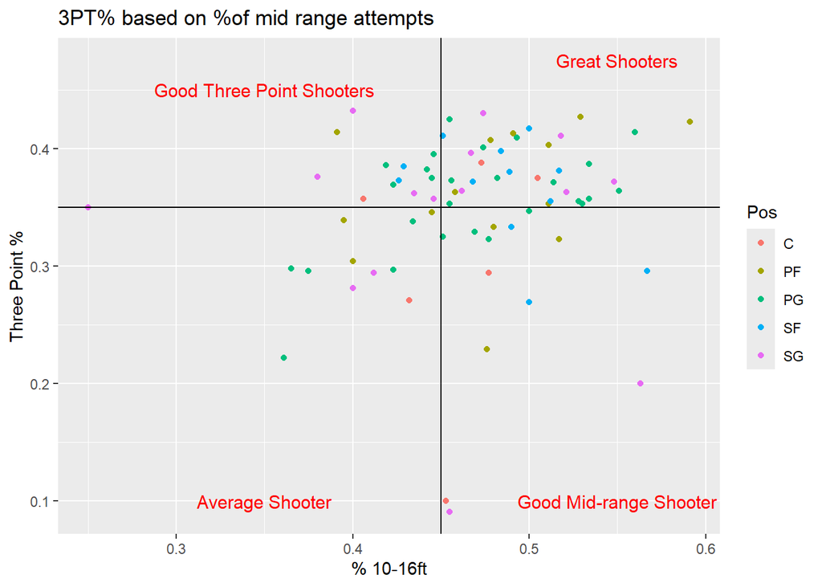

```r
ggplot(filtered_mydata4, aes(x = ten_sixteenfgperbyDistance, y = threep_fgperbyDistance))+
  geom_point(aes(color = Pos))+
  ggtitle("3PT% based on %of mid range attempts")+
  xlab("% 10-16ft")+
  ylab("Three Point %")+
  geom_hline(yintercept = .35)+
  geom_vline(xintercept = .45)+
  annotate("text", x =.55, y =.475, label = "Great Shooters", col = "red", size = 4)+
  annotate("text", x = .35, y = .45, label = "Good Three Point Shooters", col ="red", size = 4)+
  annotate("text", x = .35, y = .1, label = "Average Shooter", col  = "red", size = 4)+
  annotate("text", x =.55, y=.1, label = "Good Mid-range Shooter", col = "red", size  = 4)
```

The graph above shows shows a players three point percentage in relation to their mid range percentage. The data points are random in nature with each color representing the position that that player plays. The plot is also broken up into four different quadrants to help viewers understand how well a player shoots based on their position on the plot.

The initial thoughts from the graph is there will be little to no correlation between a players ability to make a mid range shots and their ability to make three pointers.

```r
cor(filtered_mydata4$ten_sixteenfgperbyDistance, filtered_mydata4$threep_fgperbyDistance)
```

```
## [1] 0.1603543
```

The correlation coefficient is .160, way to low to infer that there is any association between the two variables.

### **Question #3: Does a player’s position have any influence on their ability to hit three pointers?**

Finally, we will look at a player’s position on the court, and if it has any influence on their ability to shoot three pointers. Does a player’s position influence their training enough where one position would shoot much better than an other?

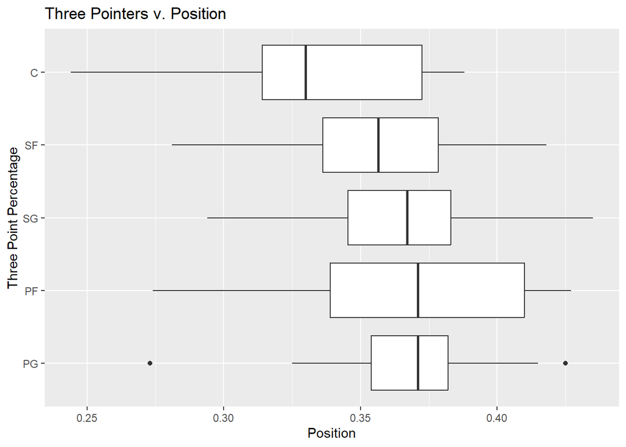

```r
ggplot(filtered_mydata1, aes(x = reorder(Pos, -threeP_percent), y = threeP_percent))+
  geom_boxplot()+
  ggtitle("Three Pointers v. Position")+
  xlab("Three Point Percentage")+
  ylab("Position")+
  coord_flip()
```

Below is a table of the average three point percentage by position.

| Position | Average Three point percentage |
| --- | --- |
| PG | .368 |
| PF | .368 |
| SG | .365 |
| SF | .356 |
| C | .335 |

This plot does not however demonstrate whether there is an association between position and three point shooting. To do that we will use the Kruskal-Wallis test. This test allows to determine if there are statically significant differences between two or more groups. In our case the groups are positions on a basketball court, and the dependent variables are the shooting percentages of those positions.

```r
kruskal.test(filtered_mydata1$threeP_percent~filtered_mydata1$Pos)
```

```
##
##  Kruskal-Wallis rank sum test
##
## data:  filtered_mydata1$threeP_percent by filtered_mydata1$Pos
## Kruskal-Wallis chi-squared = 6.5341, df = 4, p-value = 0.1627
```

From this test, we are returned several values but the one that is most important is the one titled “p-value”. The p-value is a number that describes how significantly likely a participle set of observations are to occur given the null hypothesis to be true. What we are looking for here is for our p-value to be less than .05. To keep things simple, the p-value for this experiment needs to be less than .05 for us to confidently say that the position of a player significantly impacts their ability to make three pointers. The p-value for our test is .1627, greater than .05, so no. There is no significant impact on three point shooting based on the position of a player

### **Rebuttal**

There are several limitations to this study that need to be addressed. First, there is a lack of data. There are limitations to using only one season. There could be contributing factors that influence the data. For example, the Covid lock down season or even shortened seasons. Secondly, correlation coefficients has several pitfalls and does not perfectly describe the relationship between two variables. As the famous saying goes, “correlation does not imply causation”.

### **Conclusion**

In conclusion, this report aimed to determine if any statistical data could evaluate a players ability to make three pointers at a high level. This report looked at common associations between variables such as free-trow and mid-range shooting, and uncommon associations like player positions.

Making three pointers at a high level is a difficult task. There is a lot that goes into it, and ultimately no data point can determine how well someone can make three pointers better than the eye test. To truly understand a player, you must watch and appreciate what they do. Basketball is a beautiful sport, and it is best enjoyed when one can be part of it.